# CPU Performance Anaylsis

David Parsons

Februrary 4th, 2017

[Rutgers Data 101 Blog](http://data101.cs.rutgers.edu/?q=blog)

My Data Exploration Homepage

[Rutgers Data 101 Homepage](http://data101.cs.rutgers.edu/)

## Background

My name is David Parsons, I am currently a Junior at Rutgers University majoring in Computer Science. The intent of this project was to expose my self to data exploration/analysis and the R programming language.

## Insipiration

Right now one of this biggest technological challenges facing society is the ever widening gap between the amount of data that we create and our ability to process it. Our ability process data quickly and efficiently hinges upon the Central Processing Units (CPUs) of the computing system we use. CPUs perform every single operation, calculation, and comparison that is required in for data processing. As the rate at which data in created is increases, it’s important to understand what CPU features and architectures equate to the best performance so that our processing rates can keep pace with data creation.

## The Data

Data Collected from https://vincentarelbundock.github.io/Rdatasets/datasets.html, a repo of random data sets. This data set had been curatedd as a part of a research study on estimating CPU performance.

```r
cpu <- read.csv("cpus.csv")
summary(cpu)
```

```
##        X                   name          syct             mmin
##  Min.   :  1   ADVISOR 32/60 :  1   Min.   :  17.0   Min.   :   64
##  1st Qu.: 53   AMDAHL 470/7A :  1   1st Qu.:  50.0   1st Qu.:  768
##  Median :105   AMDAHL 470V/7 :  1   Median : 110.0   Median : 2000
##  Mean   :105   AMDAHL 470V/7B:  1   Mean   : 203.8   Mean   : 2868
##  3rd Qu.:157   AMDAHL 470V/7C:  1   3rd Qu.: 225.0   3rd Qu.: 4000
##  Max.   :209   AMDAHL 470V/8 :  1   Max.   :1500.0   Max.   :32000
##                (Other)       :203
##       mmax            cach            chmin            chmax
##  Min.   :   64   Min.   :  0.00   Min.   : 0.000   Min.   :  0.00
##  1st Qu.: 4000   1st Qu.:  0.00   1st Qu.: 1.000   1st Qu.:  5.00
##  Median : 8000   Median :  8.00   Median : 2.000   Median :  8.00
##  Mean   :11796   Mean   : 25.21   Mean   : 4.699   Mean   : 18.27
##  3rd Qu.:16000   3rd Qu.: 32.00   3rd Qu.: 6.000   3rd Qu.: 24.00
##  Max.   :64000   Max.   :256.00   Max.   :52.000   Max.   :176.00
##
##       perf           estperf
##  Min.   :   6.0   Min.   :  15.00
##  1st Qu.:  27.0   1st Qu.:  28.00
##  Median :  50.0   Median :  45.00
##  Mean   : 105.6   Mean   :  99.33
##  3rd Qu.: 113.0   3rd Qu.: 101.00
##  Max.   :1150.0   Max.   :1238.00
##
```

Each CPU had the following properties:

```
sysct - cycle time in nanoseconds
mmin - minimum main memory in kilobytes
mmax - maximum main memory in kilobytes
cach - cache size in kilobytes
chmin - minimum number of channels
chmax - maximum number of channels
perf - benchmark score
```

One thing I did notice at first about this data set was that I didn’t recognize most of the manufacture names. I also didn’t notice any Intel chips, which has surprising since Intel currently owns a huge portion of the consumer CPU market. This lead me to believe that these CPUs might be server chips and/or dated technology.

## Investigation

The following is the step by step thought process I followed in exploring this data set and arriving at the conclusion I did.

### Features on Performance

I started by plotting every “feature” against performance in order to determine if any features had obvious substantial impacts performance.

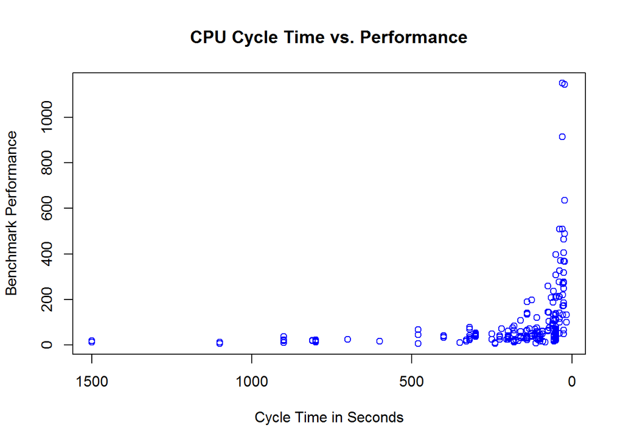

```r
perf <- cpu$perf

cycleOnPerf <- plot(cpu$syct, perf, main="CPU Cycle Time vs. Performance", xlab = "Cycle Time in Seconds", ylab = "Benchmark Performance", xlim = rev(range(cpu$syct)), col = "blue")
```

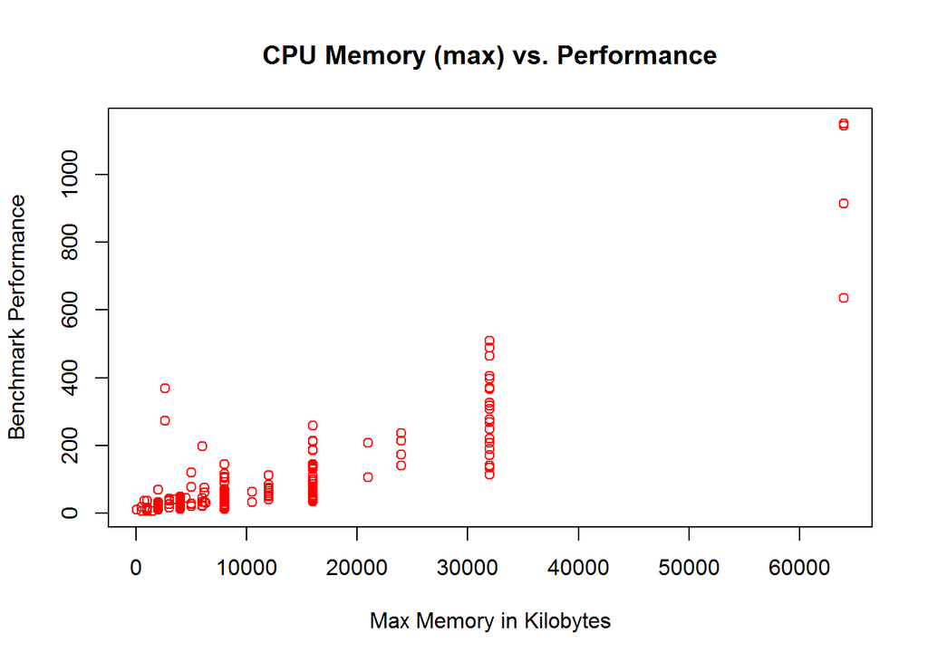

```r
memMaxOnPerf <- plot(cpu$mmax, perf, main="CPU Memory (max) vs. Performance", xlab = "Max Memory in Kilobytes", ylab = "Benchmark Performance", col = "red")
```

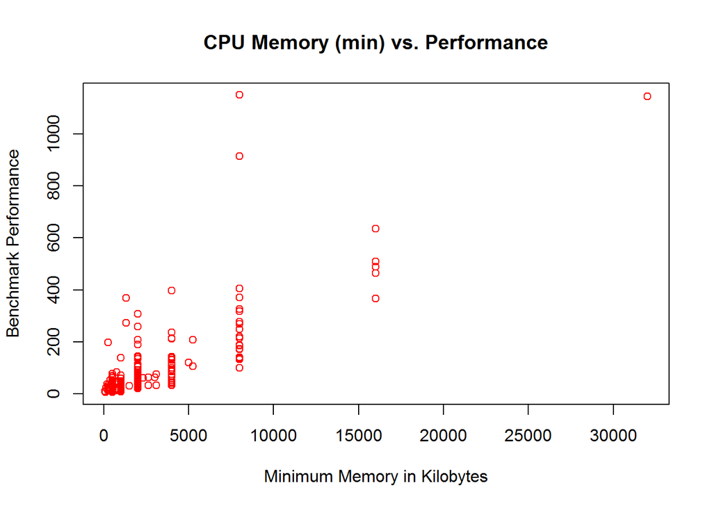

```r
memMinOnPerf <- plot(cpu$mmin, perf, main="CPU Memory (min) vs. Performance", xlab = "Minimum Memory in Kilobytes", ylab = "Benchmark Performance", col = "red")
```

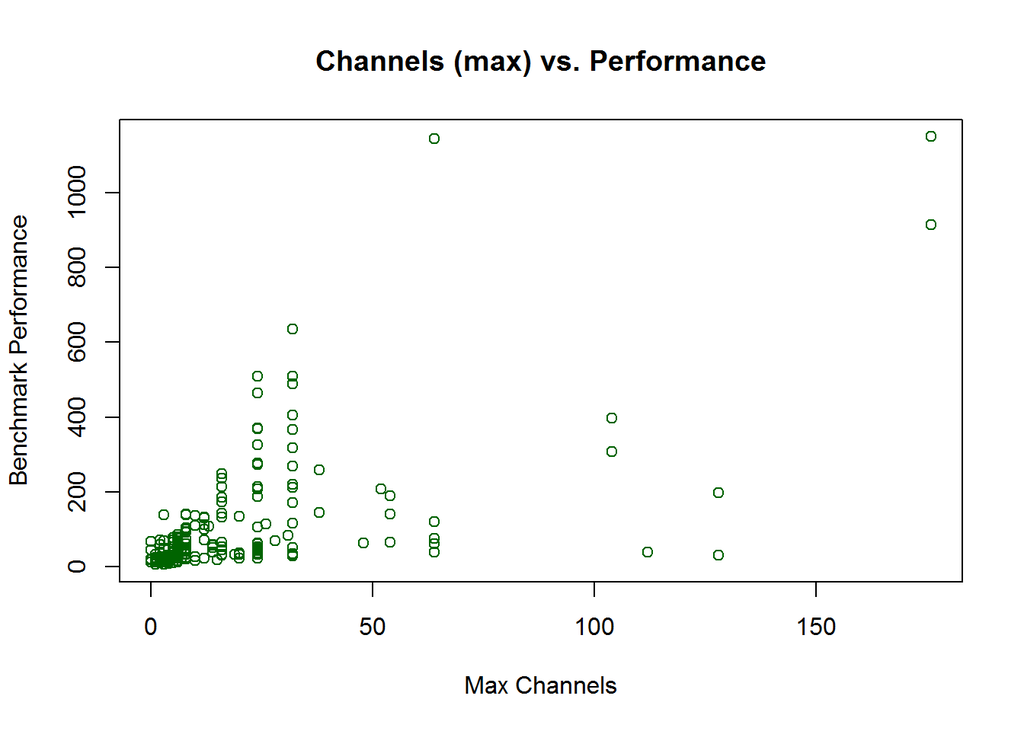

```r
chanMaxOnPerf <- plot(cpu$chmax, perf, main="Channels (max) vs. Performance", xlab = "Max Channels", ylab = "Benchmark Performance", col = "darkgreen")
```

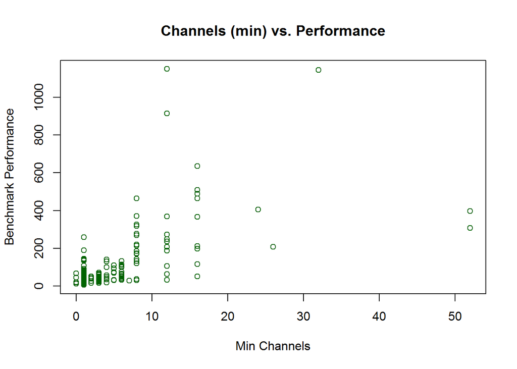

```r
chanMinOnPerf <- plot(cpu$chmin, perf, main="Channels (min) vs. Performance", xlab = "Min Channels", ylab = "Benchmark Performance", col = "darkgreen")
```

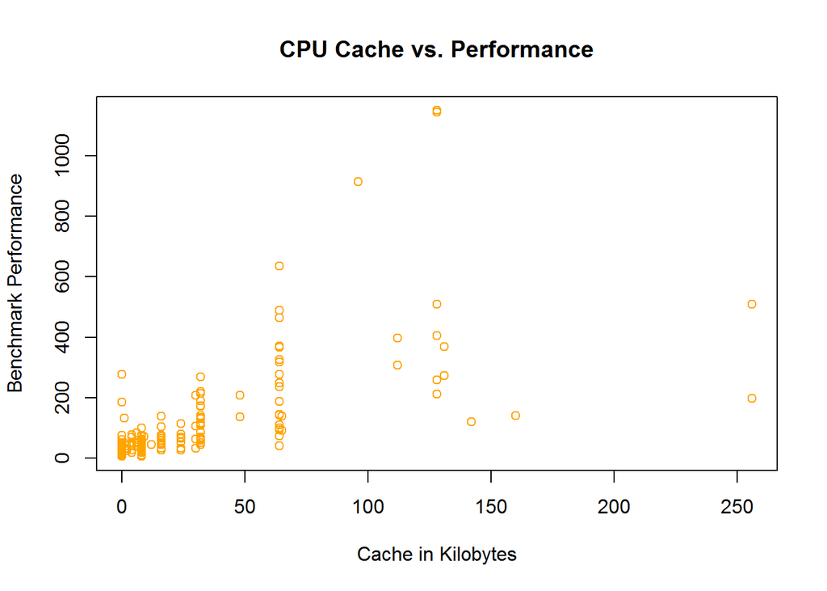

```r
cacheOnPerf <- plot(cpu$cach, perf,main="CPU Cache vs. Performance", xlab = "Cache in Kilobytes", ylab = "Benchmark Performance", col = "orange")
```

### Observation 1 - Cycle Time

There is a clear correlation between a decrease in cycle time and an increase in performance.

This may seem obvious to some, since lower “cycle times” (a cycle is basically how long is takes the CPU to perform one operation) equate to more computations in less time (higher frequency).

The CPUs scoring in the ninetieth percentile on the performance benchmark were among the lowest cycle times.

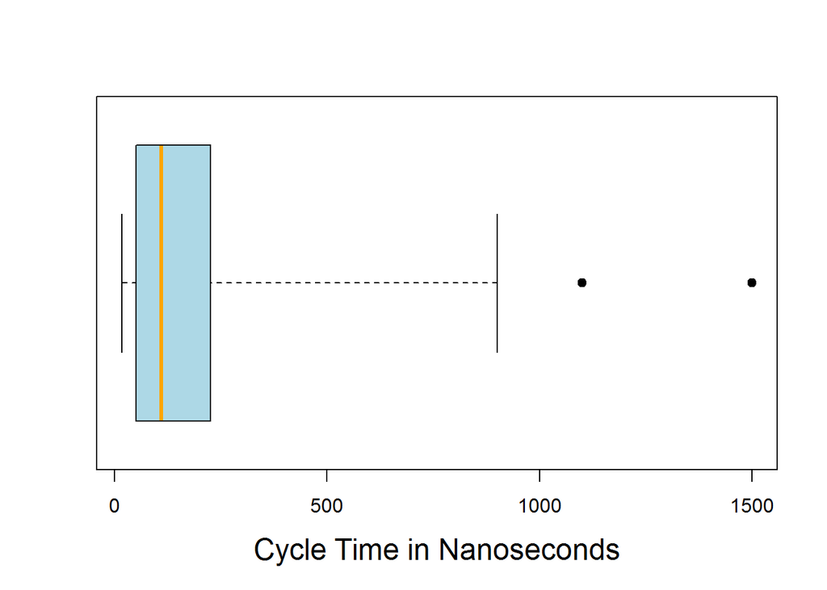

```r
cycleTBox <- boxplot(cpu$syct, data = cpu, xlab = "Cycle Time in Nanoseconds",col = "lightblue", medcol = "orange", bg = "blue", range = 4, cex.main=2,cex.lab=1.5, horizontal = TRUE, varwidth = TRUE, pch = 19)
```

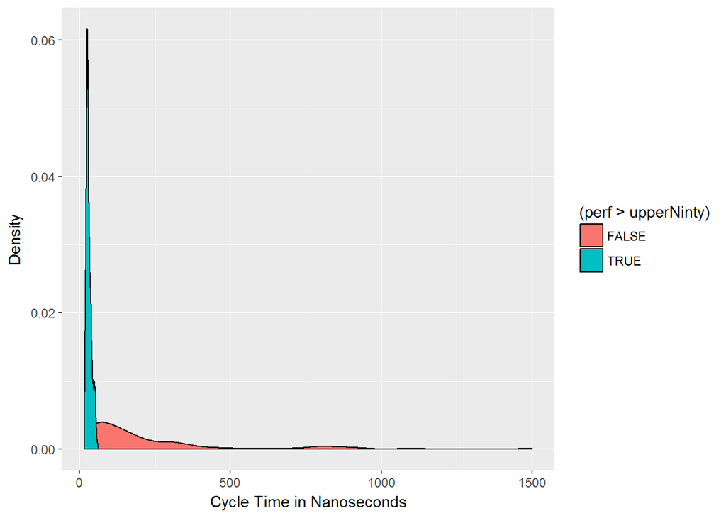

```r
upperNinty = as.numeric(quantile(cpu$perf, 0.9))

ggplot(cpu,aes(syct, fill = (perf > upperNinty)))+geom_density()+scale_x_continuous(name = "Cycle Time in Nanoseconds")+scale_y_continuous(name = "Density")
```

But faster cycle times do not directly equate to the best performance.

```
- CPU's with the same minimal cycle time had drastically different benchmark scores.
```

While cycle time is clearly important to performance it alone does not define a chips performance.

### Observation 2 - Main Memory

Having to little memory can create a bottleneck for a CPU’s performance.

[output not shown]

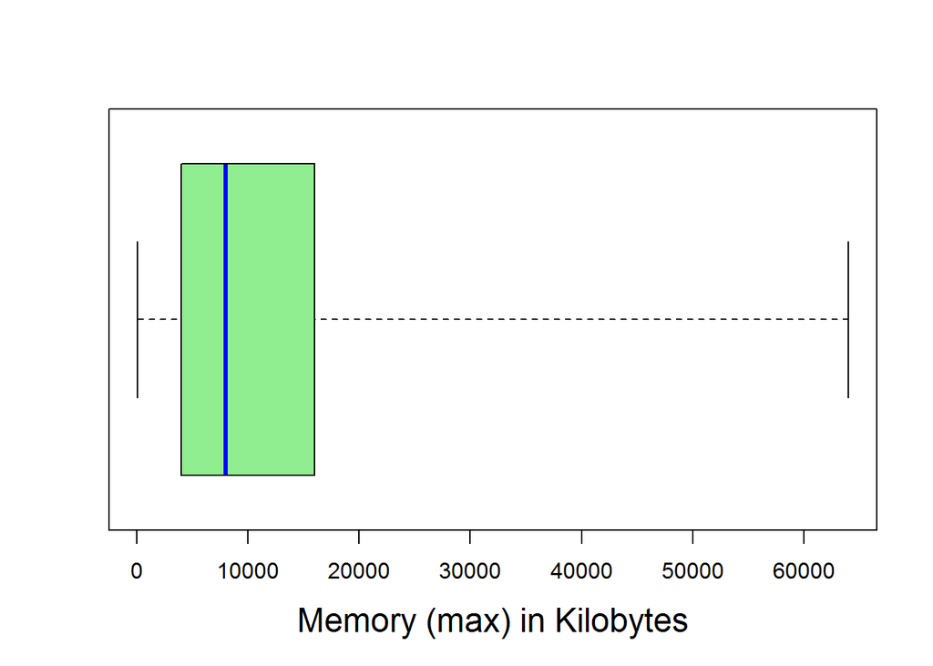

```r
cycleTBox <- boxplot(cpu$mmax, data = cpu, xlab = "Memory (max) in Kilobytes",col = "lightgreen", medcol = "blue", bg = "blue", range = 4, cex.main=2,cex.lab=1.5, horizontal = TRUE, varwidth = TRUE, pch = 19)
```

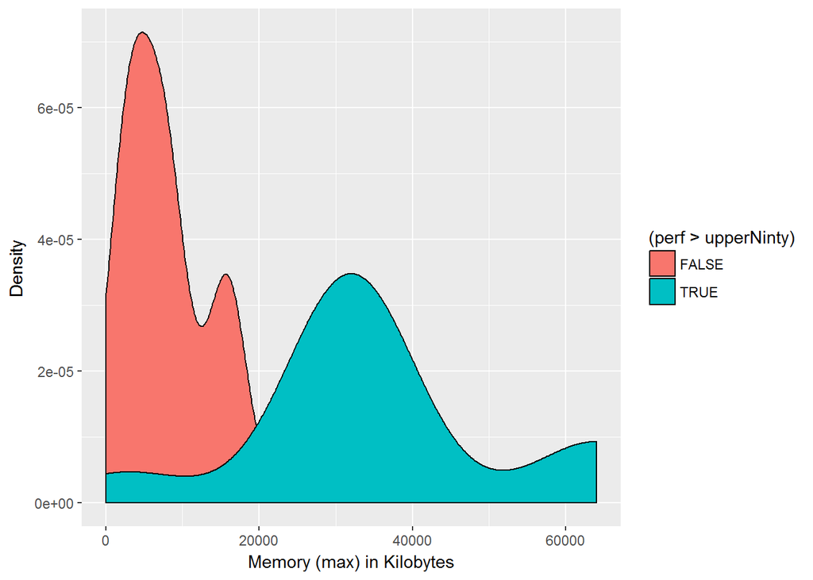

```r
upperNinty = as.numeric(quantile(cpu$perf, 0.9))

ggplot(cpu,aes(mmax, fill = (perf > upperNinty)))+geom_density()+geom_density()+scale_x_continuous(name = "Memory (max) in Kilobytes")+scale_y_continuous(name = "Density")
```

But apart from the few “outliers”, an increase in memory only correlates to an increase in performance to a certain extent.

[output not shown]

### Observation 3 - Cache Size

The story here seems to be quite similar to the memory and again isn’t surprising, especially since cache is just a type of memory (albeit functionally quite different from main memory).

In theory more cache should equate to better performance, but

```
- Some CPUs with 0 cache scored in the 90th percentile.
- Top CPUs outperformed other CPUs with more cache
```

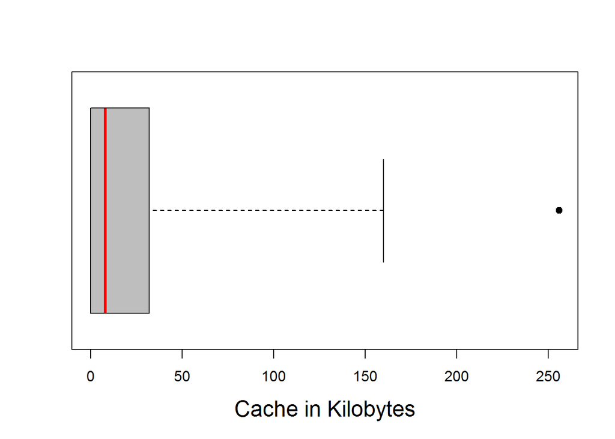

```r
cacheBox <- boxplot(cpu$cach, data = cpu, xlab = "Cache in Kilobytes",col = "grey", medcol = "red", bg = "blue", range = 4, cex.main=2,cex.lab=1.5, horizontal = TRUE, varwidth = TRUE, pch = 19)
```

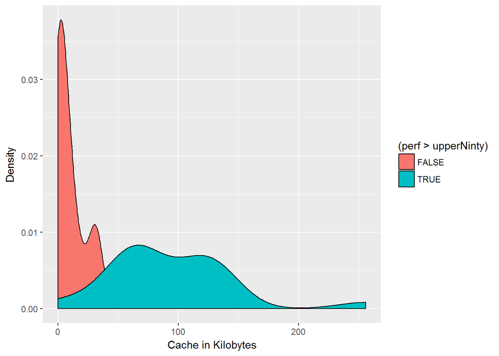

```r
upperNinty = as.numeric(quantile(cpu$perf, 0.9))

ggplot(cpu,aes(cach, fill = (perf > upperNinty)))+geom_density()+geom_density()+scale_x_continuous(name = "Cache in Kilobytes")+scale_y_continuous(name = "Density")
```

The extent to which cache improves performance appears to be much sharper than the level seen with main memory.

### Conlusion & Next Steps

There isn’t a particular “feature” that seemed to provide THE best performance increase. None of these features had such a drastic effect on performance that it stood out.

But of the 3 observations, the amount Main Memory appears to be the most restrictive on performance.

A heat map might help to demonstrate what combination of features is the most beneficial for increasing performance.

It’s also very possible other factors/“features” are effecting performance like CPU architecture, temperature, power draw, compute cores, etc. A performance metric that takes into account these other features might be a more accurate depiction of a “good” CPU.

Price to Performance might also be an interesting metric to investigate and how it relates to the value and trade-offs associated with certain “features”.

The fastest cycle time was 17 nanoseconds, which equates to about 58 MHz or 0.06 GHz, which is very slow compared to modern CPUs. So there may be other bottlenecks with these CPUs, and it’d be interesting to replicate this analysis on modern consumer CPUs.

## Notes and Comments

This was my first time doing any sort of analysis like this and it was quite an interesting experience. While I found the coorelations that I found interesting, I was constantly thinking about the fact that they were just merely correlations.

The conclusions I jumped to, didn’t always feel sound. I think that is something that might just be inherent to data analysis, but the feeling was amplified by my lack of experience.

It should be interesting to see how the way in which I go about finding and making conclusions evolves as I work with more and larger data sets.

[Rutgers Data 101 Blog](http://data101.cs.rutgers.edu/?q=blog)

My Data Exploration Homepage

[Rutgers Data 101 Homepage](http://data101.cs.rutgers.edu/)